# Analytics Capstone

Lorena Dominguez & Ruochen Sun

February 23, 2017

```r
print(getwd())
```

```
[1] "/Users/loredp/Dropbox (MIT)/MIT/Capstone/capstone"
```

```r
knitr::opts_knit$set(root.dir = '/Users/loredp/Dropbox (MIT)/MIT/Capstone')
print(getwd())
```

```
[1] "/Users/loredp/Dropbox (MIT)/MIT/Capstone/capstone"
```

# Problem description

This project aims to provide Nordstrom’s buying teams with predictive models that inform both the selection breadth and depth at a category and supplier level for their online business. This will be executed through a series of steps that consist of:

1. Initial exploratory data analysis
2. Formulation of demand model
3. Formulation of optimization model

## Scope

The project will be limited to women’s handbags, although the analysis will be segmented into 2 departments/categories: Bridge and Contemporary.

The project requires working with historical sales data to perform sales forecasting and create the selection model. Different statistical and machine learning techniques will be researched and explored to develop a demand prediction model. Finally, those clear and accessible data products will be applied in the final optimized selection strategy and assist the stakeholders in taking action on real business decisions.

# Data

Data has been shared via Dropbox and will be updated by the Nordstrom team on a continuous basis. Current available data will be used to build the demand model and consists on: 1. Historical transactions: purchase and return transactions from 02/13 to 01/17

2. Product hierarchy: product attributes such as color, brand, style, etc.
3. Product catalog: Original price and color family for each product
4. Price type: regular, clearance, anniversary, promotion
5. Fiscal calendar
6. Events calendar: includes special sales like Thanksgiving or Christmas Additional data around costs and optimization constraints required for the optimization model will be provided when the on-site internship starts. Any additional data that we deem necessary will be provided on-site as well.

# Exploratory Analysis

First step was to load and explore datasets. We started working on the transactions dataset. There is a total of 1570231 observations, although it includes sales and returns, so we have to subset the information.

### Question 1: How to deal with returns?

|  | SKU_IDNT | UNITS | DEMAND | RTRN_UNITS | RTRN_AMT | DAY_DT | UNIT_PRICE | UNITS + RTRN_UNITS |
| --- | --- | --- | --- | --- | --- | --- | --- | --- |
| 1 | 58274618 | 525 | 45664.50 | 3 | -43.47 | 2015-06-16 | 86.9800 | 528 |
| 2 | 87256946 | 501 | 43576.98 | 2 | -28.98 | 2015-06-16 | 86.9800 | 503 |
| 3 | 92788315 | 494 | 42968.12 | 11 | -119.39 | 2016-06-14 | 86.9800 | 505 |
| 4 | 87256942 | 489 | 42533.22 | 6 | -238.48 | 2015-06-16 | 86.9800 | 495 |
| 5 | 85134862 | 459 | 85995.22 | 2 | -154.34 | 2016-11-24 | 187.3534 | 461 |
| 6 | 92788318 | 448 | 38967.04 | 9 | -112.21 | 2016-06-14 | 86.9800 | 457 |

### Time series of demand

First, we focused on the demand and excluded all returns:

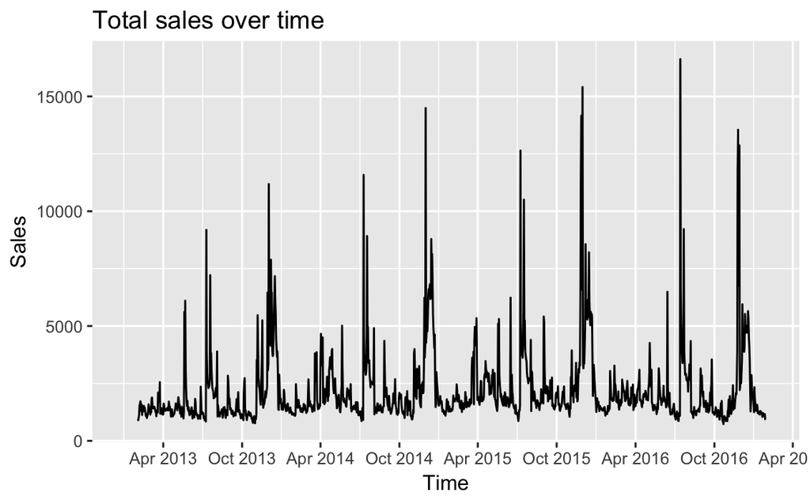

```r
demand <- tran %>%
    filter(!is.na(UNITS)) %>%
    select(DAY_DT, SKU_IDNT, UNITS, DEMAND, UNIT_PRICE)
demand_date <- demand %>%
    group_by(DAY_DT) %>%
    summarize(total_units = sum(UNITS), total_demand = sum(DEMAND))%>%
    arrange(DAY_DT)
startTime <- as.Date("2013-01-01")
endTime <- as.Date("2017-02-01")
# create a start and end time R object
start.end <- c(startTime,endTime)
ggplot(data = demand_date, aes(DAY_DT, total_units)) + geom_line() + xlab("Time") + ylab("Sales")+
    scale_x_date(limits=start.end, date_breaks = "6 months", date_labels = "%b %Y")+
    ggtitle("Total sales over time ")
```

### Events

[figure not shown]

```r
demand_events <- demand_date%>%
    mutate(ym = as.yearmon(DAY_DT)) %>%
    left_join(events) %>%
    mutate(event = ifelse(DAY_DT>= start & DAY_DT <= end,1,0)) %>%
    filter(event == 1) %>%
    group_by(name) %>%
    summarize(total_units = sum(total_units),
              total_demand = sum(total_demand),
              duration = as.numeric(sum(duration))) %>%
    mutate(units_per_day = total_units/duration,
           demand_per_day = total_demand/duration)%>%
    select(-duration) %>%
    arrange(name)
ggplot(data=demand_events, aes(factor(name),total_units))+
    geom_bar(stat="identity")+coord_flip() + ylab('Event')+
    xlab('Total units')+ggtitle('Units sold per day for special events')
```

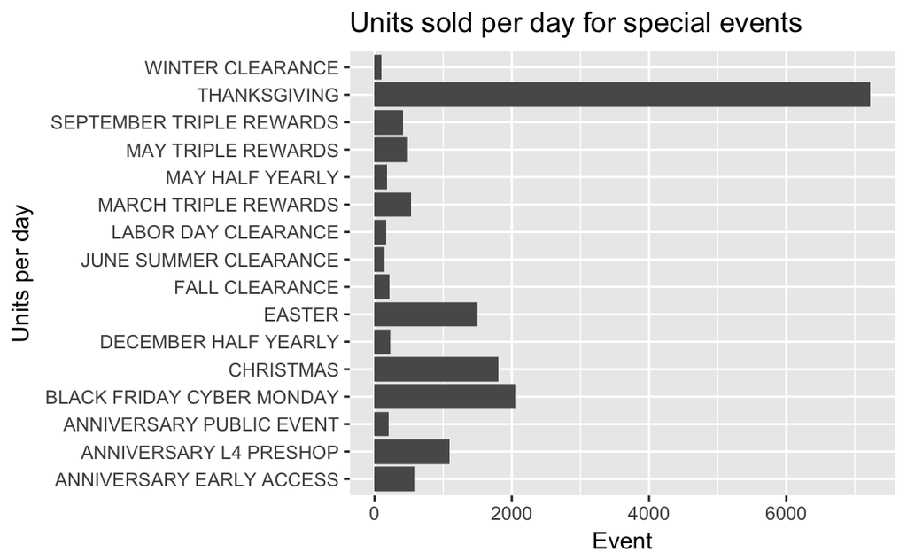

```r
ggplot(data=demand_events, aes(factor(name),units_per_day))+
    geom_bar(stat="identity")+coord_flip() + ylab('Event')+
    xlab('Units per day')+ggtitle('Units sold per day for special events')
```

### Color

```r
color= str_split_fixed(hier$SUPP_COLOR  , "/",2)
```

```
Error: could not find function "str_split_fixed"
```

## Aggregate by month

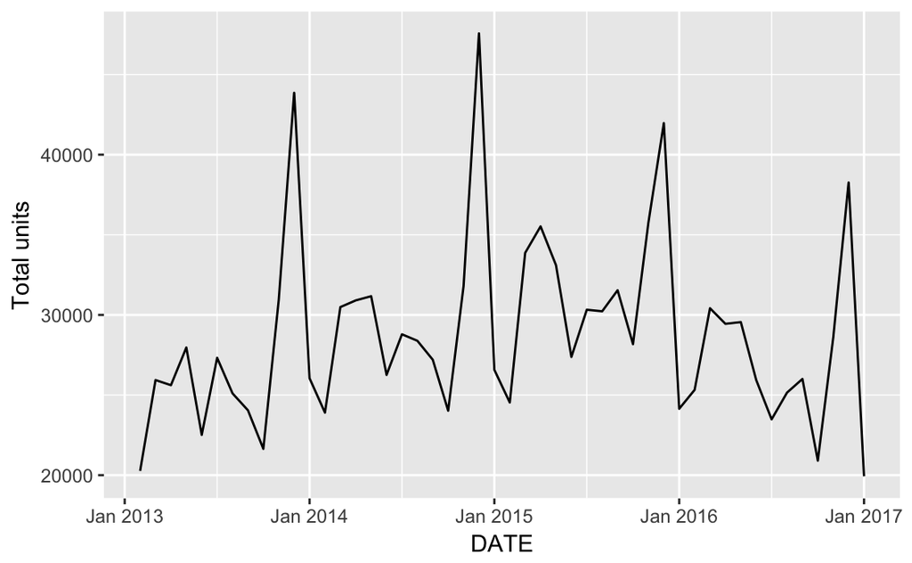

## PRICES

```r
tran_cat <- demand %>%
    inner_join(catalog, by = "SKU_IDNT") %>%
    select(-c(CRT_TMSTP, RCD_UPDT_TMSTP)) %>%
    left_join(price_type)
tran_cat2 <- tran_cat %>%
    mutate(PRICE_TYPE = ifelse(is.na(PRICE_TYPE),'REGULAR',PRICE_TYPE)) %>%
    group_by(SKU_IDNT, PRICE_TYPE)%>%
    summarize(total_units = sum(UNITS))
tran_cat_hor <- tran_cat2 %>%
    spread(PRICE_TYPE,total_units)
```

```
Error in function_list[[k]](value) : could not find function "spread"
```

## Department

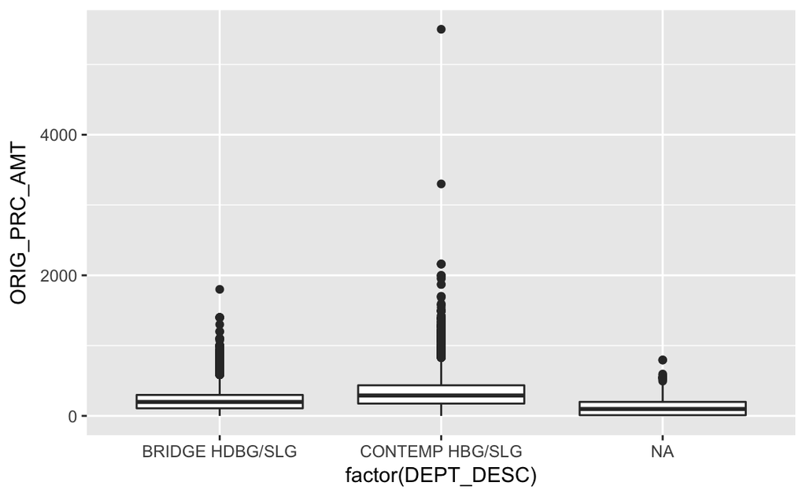

### Further steps:

1. Look at attributes (colors, size, department, base model)
2. Focus on regular and promotion price
3. Discount returns